# 2.4-microbial_metagenomics_hmsc

Luisa Santos-Bay & Antton Alberdi

2024-01-22

## Load libraries

```r
suppressPackageStartupMessages(library(tidyverse))
suppressPackageStartupMessages(library(phyloseq))
suppressPackageStartupMessages(library(Hmsc))
suppressPackageStartupMessages(library(distillR))
suppressPackageStartupMessages(library(ggplot2))
suppressPackageStartupMessages(library(ggtree))
suppressPackageStartupMessages(library(ggnewscale))
suppressPackageStartupMessages(library(ggtreeExtra))
suppressPackageStartupMessages(library(gridExtra))
suppressPackageStartupMessages(library(phytools))
suppressPackageStartupMessages(library(knitr))
```

## Load data

```r
load("data/data.Rdata")
```

## Prepare input for Hmsc

Hmsc requires input object to be formatted in a very specific way. In the following chunk the ramdom effects, fixed effects, read counts and genome phylogeny are declared.

```r
# Random effects data (study design)
StudyDesign <- sample_metadata %>%
                    filter(!is.na(dominance)) %>%
                    select(sample,animal,cage) %>%
                    mutate(cage = factor(cage)) %>%
                    mutate(animal = factor(animal)) %>%
                    distinct() %>%
                    column_to_rownames("sample")

# Genome count table (quantitative community data)
YData <- read_counts  %>%
                    mutate(across(where(is.numeric), ~ . +1 )) %>% #add +1 pseudocount to remove zeros
                    mutate(across(where(is.numeric), ~ . / (genome_metadata$length / 150) )) %>% #transform to genome counts
                    mutate(across(where(is.numeric), ~  log(.) )) %>% #log-transform
                    column_to_rownames("genome") %>%
                    select(all_of(row.names(StudyDesign))) %>%  #filter only faecal samples
                    as.data.frame() %>%
                    t() # transpose

# Fixed effects data (explanatory variables)
XData1 <- sample_metadata %>%
                    filter(sample %in% rownames(StudyDesign)) %>%
                    distinct() %>%
                    select(sample,group,dominance) %>%
                    mutate(logseqdepth=read_counts %>% #total log-sequencing depth
                        select(all_of(row.names(StudyDesign))) %>%
                        colSums() %>%
                        log()
                    ) %>%
                    mutate(group = factor(group)) %>%
                    column_to_rownames("sample")

# Genome phylogeny
PData <- genome_tree
```

## Define formulas of the Hmsc model

Once the input data are ready, it is time for defining the formulas that will structure the model. In our case, the temporal dynamic of microbial communities will be modelled in light of the dominance indices of mice, while adding group (variable or invariable environment) and log-sequencing depth (the sequencing effort per sample) as covariates. Lastly, animal ID and cage ID are declared as random effects to control for the longitudinal aspect of the study (multiple samples per animal) and the housing structure (5 animals per cage).

```r
# Fixed effects formula
XFormula1 = ~dominance + group + logseqdepth

# Study design
rL.animal = HmscRandomLevel(units = levels(StudyDesign$animal))
rL.cage = HmscRandomLevel(units = levels(StudyDesign$cage))
```

## Define and Hmsc models

The following chunk generates the Hmsc model that we will later fit in the high computation cluster. In this case there will be a single model called ‘model1’.

```r
#Define models
model1 = Hmsc(Y=YData,
         XData = XData1,
         XFormula = XFormula1,
         studyDesign = StudyDesign,
         phyloTree = PData,
         ranLevels = list("animal"=rL.animal, "cage"=rL.cage),
         distr = "normal",
         YScale = TRUE)

#Save list of models as an R object.
model_list = list(model1=model1)
if (!dir.exists("hmsc")){dir.create("hmsc")}
save(model_list, file = "hmsc/hmsc.Rdata")
```

Upload **hmsc/hmsc.Rdata** to the HPC respecting the directory structure.

## Define MCMC

The next step is to define the parameters of the MCMC process for model fitting. In this case we opt for a single number of samplings (250), two thinning values (1 and 10), and 4 chains. This means that once the burn-in part is removed, each of the four MCMC chains will be sampled 250 times either with an interval of 1 or 10 iterations. Note that the 4x250x10 option is about 10 times slower than 4x250x1, although the probability for parameter convergence is increased.

```r
# How often to sample the MCMC
MCMC_samples_list = 250

# The number of MCMC steps between each recording sample
MCMC_thin_list = c(1, 10)

# The number of MCMC chains to use
nChains = 4
```

## Generate Hmsc executables

The next chunk generates shell files for every combination of model, MCMC samples and MCMC thinning, ready to be launched as SLURM jobs. This is because Hmsc requires a notable amount of memory and long computation times, which renders impossible to run most fitting processes in personal computers.

```r
modelchains <- expand.grid(model = names(model_list), sample = MCMC_samples_list, thin = MCMC_thin_list)

if (!dir.exists("hmsc")){dir.create("hmsc")}
for(i in c(1:nrow(modelchains))){
      modelname=as.character(modelchains[i,1])
      sample=modelchains[i,2]
      thin=modelchains[i,3]
      executablename <- paste0("hmsc/exe_",modelname,"_",sample,"_",thin,".sh")
      fitname <- paste0("hmsc/fit_",modelname,"_",sample,"_",thin,".Rdata")
      convname <- paste0("hmsc/conv_",modelname,"_",sample,"_",thin,".Rdata")
      model <- paste0('model_list$',modelname)
      psrf.beta.name <-  paste0("psrf.beta.",modelname,"_",sample,"_",thin)
      psrf.gamma.name <-  paste0("psrf.gamma.",modelname,"_",sample,"_",thin)
      psrf.rho.name <-  paste0("psrf.rho.",modelname,"_",sample,"_",thin)
      jobname <- paste0("hmsc_",modelname,"_",sample,"_",thin)
      minutes <- round(sample * thin * (ncol(YData) * nrow(YData)/50000), 0)
      code <- sprintf("#!/bin/bash
#SBATCH --job-name=%s                   # Job name
#SBATCH --nodes=1
#SBATCH --ntasks=4                      # Run on 4 CPUs
#SBATCH --mail-user=antton.alberdi@sund.ku.dk
#SBATCH --mem=800gb                      # Job memory request
#SBATCH --time=%d                       # In minutes

# Activate conda environment
module load mamba/1.3.1
source activate /maps/projects/mjolnir1/people/jpl786/AMAC001_fibre_trial/hmsc/hmsc_env

# Run R script
Rscript -e '
library(tidyverse)
library(Hmsc)
# Load formulas and data
load(\"hmsc/hmsc.Rdata\")

# Declare placeholders
modelname = \"%s\"
model = %s
fitname = \"%s\"
convname = \"%s\"
sample = %d
thin = %d
nchains = %d

# Run model fitting
m = sampleMcmc(hM = model,
         samples = sample,
         thin = thin,
         adaptNf=rep(ceiling(0.4*sample*thin),model$nr),
         transient = ceiling(0.5*sample*thin),
         nChains = nchains,
         nParallel = nchains)

# Assess chain convergence
mpost = convertToCodaObject(m,
      spNamesNumbers = c(T,F),
      covNamesNumbers = c(T,F),
      Beta = TRUE,
      Gamma = TRUE,
      V = FALSE,
      Sigma = FALSE,
      Rho = TRUE,
      Eta = FALSE,
      Lambda = FALSE,
      Alpha = FALSE,
      Omega = FALSE,
      Psi = FALSE,
      Delta = FALSE) # Convert to CODA object

# Fixed effects
assign(paste0(\"psrf.beta.\", modelname,\"_\",sample,\"_\",thin), gelman.diag(mpost$Beta,multivariate=FALSE)$psrf)

# Traits
assign(paste0(\"psrf.gamma.\", modelname,\"_\",sample,\"_\",thin), gelman.diag(mpost$Gamma,multivariate=FALSE)$psrf)

# Phylogeny
assign(paste0(\"psrf.rho.\", modelname,\"_\",sample,\"_\",thin), gelman.diag(mpost$Rho,multivariate=FALSE)$psrf)

# Write convergence data
save(%s, %s, %s, file=convname)

# Save model fit object
save(m, file=fitname)
'
", jobname, minutes, modelname, model, fitname, convname, sample, thin, nChains, psrf.beta.name, psrf.gamma.name, psrf.rho.name)
      writeLines(code, executablename)
    }
```

Upload the produced **hmsc/exe_XXXXX.sh** files to the HPC respecting the directory structure.

## Fit Hmsc models (in Mjolnir HPC)

Launch the SLURM jobs by using:

```bash
# Submit all .sh files in the hmsc folder
for jobfile in hmsc/exe_*.sh; do
    sbatch "$jobfile"
done

#Or launch them one by one only the ones you want to launch
sbatch hmsc/exe_model1_250_1.sh
sbatch hmsc/exe_model1_250_10.sh
```

When the task is done download the produced **hmsc/conv_XXXXX.Rdata** and **hmsc/fit_XXXXX.Rdata** files to your computer. The ‘conv’ file only contains the information required for assessing model convergence, while the file ‘fit’ contains all the information of the fitted model, hence its large size.

## Assess chain convergence

The ‘conv’ file is used to assess whether the multiple MCMC chains ran for model fitting converged, i.e., whether all parameters reached similar values. Convergence diagnostic values substantially above 1 indicate lack of convergence, while values below 1.1 are usually considered good enough.

```r
# Load all conv file available in the hmsc folder
list.files(path = "hmsc", pattern = "^conv_", full.names = TRUE, include.dirs = TRUE) %>%
  lapply(.,load,.GlobalEnv)

# Create a merged psrf.beta (genome) plot
ls() %>%
        grep("^psrf\\.beta", ., value = TRUE) %>%
        map_dfr(~ {
         mat <- get(.x)
          data.frame(modelchain = .x, as.data.frame(mat, , stringsAsFactors = FALSE)) %>%
              rownames_to_column(var="parameter") %>%
              mutate(model = str_split(modelchain, "_") %>% map_chr(1) %>% gsub("psrf.beta.","",.)) %>%
              mutate(sample = str_split(modelchain, "_") %>% map_chr(2)) %>% #extract sample info from model name
              mutate(thin = str_split(modelchain, "_") %>% map_chr(3)) #extract thin info from model name
      }) %>%
      ggplot(.,aes(x=reorder(modelchain,-Point.est.,fun=function(x) {quantile(x, probs = 0.9)}),y=Point.est.)) +
        geom_violin(fill="#b8d9e3", color="#328da8") +
        geom_jitter(alpha=0.3,size=0.2, color="#a8babf") +
        stat_summary(fun=function(x) {quantile(x, probs = 0.9)}, geom="crossbar", width=0.2, color="orange") +
        geom_hline(yintercept=1.1, linetype="dashed", color = "red") +
        ylim(0.9,2)+
        labs(x="Model chains",y="Parameter estimates")+
        theme_classic()

# Create a merged psrf.rho (phylogeny) plot
ls() %>%
        grep("^psrf\\.rho", ., value = TRUE) %>%
        map_dfr(~ {
         mat <- get(.x)
          data.frame(modelchain = .x, as.data.frame(mat, , stringsAsFactors = FALSE)) %>%
              rownames_to_column(var="parameter") %>%
              mutate(model = str_split(modelchain, "_") %>% map_chr(1) %>% gsub("psrf.rho.","",.)) %>%
              mutate(sample = str_split(modelchain, "_") %>% map_chr(2)) %>% #extract sample info from model name
              mutate(thin = str_split(modelchain, "_") %>% map_chr(3)) #extract thin info from model name
      }) %>%
      ggplot(.,aes(x=reorder(modelchain,-Point.est.,fun=function(x) {quantile(x, probs = 0.9)}),y=Point.est.)) +
        geom_violin(fill="#b8d9e3", color="#328da8") +
        geom_jitter(alpha=0.3,size=0.2, color="#a8babf") +
        stat_summary(fun=function(x) {quantile(x, probs = 0.9)}, geom="crossbar", width=0.2, color="orange") +
        geom_hline(yintercept=1.1, linetype="dashed", color = "red") +
        ylim(0.9,2)+
        labs(x="Model chains",y="Parameter estimates")+
        theme_classic()
```

[output not shown]

## Compute variance partitioning

Once the chain convergence has been validated, we can visualise how the variance of each genome is explained by the different variables employed in the modelling.

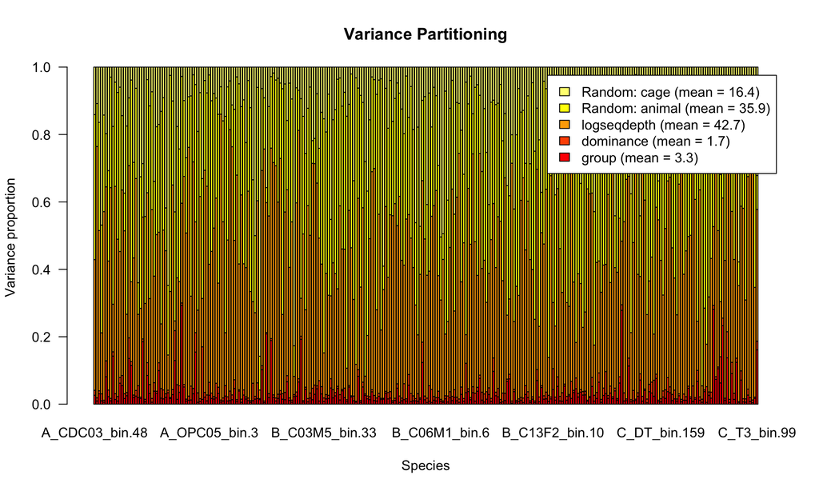

```r
# Select modelchain of interest
load("hmsc/fit_model1_250_1.Rdata")

varpart=computeVariancePartitioning(m)
plotVariancePartitioning(hM=m,VP=varpart)
```

The summary statistics indicate that sequencing depth and the animal random effect explain most of the variation, which highlight the importance of controlling for these features when modelling. There is a substantial cage effect, indicating that the microbiome properties are more alike among cage mates. The two variables that explain the lowest portion of the variance are the experimental group (variable or invariable environment) and dominance index, highlighting that the effect sizes of dominance are rather low.

## Get posterior estimates

```r
support=0.05
supportneg=1-support

postestimate <- getPostEstimate(
                  hM=m,
                  parName="Beta")

# Get estimates for dominance
postestimate_support <- postestimate$support %>%
  as.data.frame() %>%
  slice(3) %>%  #select dominance posteriors
  t() %>%
  as.data.frame() %>%
  rename(posterior=V1) %>%
  mutate(trend = ifelse(posterior < support, "Negative", "Neutral"))  %>%
  mutate(trend = ifelse(posterior > supportneg, "Positive", trend)) %>%
  select(trend)

# Positive
genomes_pos <- postestimate_support %>%
        rownames_to_column(var="genome") %>%
        filter(trend == "Positive") %>%
        select(genome) %>% pull()

# Negative
genomes_neg <- postestimate_support %>%
        rownames_to_column(var="genome") %>%
        filter(trend == "Negative") %>%
        select(genome) %>% pull()

#hmsc built-in function
#plotBeta(hM=m, post=postestimate,supportLevel = 0.95, plotTree=T)
```

### Positively associated genomes

```r
  genome_metadata %>%
    filter(genome %in% genomes_pos) %>%
    select(genome, phylum, order, species, completeness, contamination) %>%
    left_join(postestimate$mean %>%
                  as.data.frame() %>%
                  slice(3) %>% t() %>%
                  as.data.frame() %>%
                  rename(beta=1) %>%
                  rownames_to_column(var="genome"), by=join_by(genome==genome)) %>%
    arrange(-beta) %>%
    kable()
```

| genome | phylum | order | species | completeness | contamination | beta |
| --- | --- | --- | --- | --- | --- | --- |
| A_HTC12_bin.48 | p__Bacillota | o__Lactobacillales | s__Lactobacillus johnsonii | 98.19 | 0.000 | 0.6820749 |
| B_C06M5_bin.62 | p__Bacillota_A | o__Christensenellales | s__CAG-475 sp910577815 | 90.82 | 0.041 | 0.6618905 |
| C_HT_bin.102 | p__Bacillota | o__Lactobacillales | s__Limosilactobacillus reuteri | 97.82 | 0.000 | 0.4832454 |
| B_C13F3_bin.57 | p__Bacillota_A | o__Oscillospirales | s__Dysosmobacter sp910583785 | 95.57 | 2.732 | 0.4124360 |
| A_DTC13_bin.55 | p__Bacillota_A | o__Christensenellales | s__RACS-045 sp910579785 | 94.85 | 0.000 | 0.4032097 |
| A_CDC13_bin.13 | p__Bacillota_A | o__Lachnospirales | s__UBA3402 sp002358555 | 97.46 | 0.158 | 0.3712604 |
| A_HTC03_bin.32 | p__Bacillota_A | o__Oscillospirales | s__Pelethomonas sp910587645 | 95.17 | 0.671 | 0.3681985 |
| A_T1C10_bin.3 | p__Bacteroidota | o__Bacteroidales | s__UBA7173 sp002491305 | 98.67 | 0.377 | 0.3560440 |
| A_DRC05_bin.59 | p__Bacteroidota | o__Bacteroidales | s__Duncaniella sp910577345 | 99.43 | 0.377 | 0.3486272 |
| A_DTC03_bin.77 | p__Bacteroidota | o__Bacteroidales | s__CAG-873 sp910586975 | 97.54 | 0.000 | 0.3365382 |
| B_C11F3_bin.29 | p__Bacillota_A | o__Lachnospirales | s__CAG-95 sp009911035 | 97.12 | 1.149 | 0.3202246 |
| A_OPC10_bin.79 | p__Bacillota_A | o__Lachnospirales | s__UBA3402 sp910574345 | 99.36 | 1.265 | 0.3160747 |
| B_C05M1_bin.76 | p__Pseudomonadota | o__Enterobacterales | s__Escherichia coli | 99.92 | 0.142 | 0.3110820 |
| A_T3C12_bin.34 | p__Bacteroidota | o__Bacteroidales | s__CAG-485 sp009775355 | 97.61 | 0.377 | 0.3035276 |
| B_C04M5_bin.101 | p__Bacteroidota | o__Bacteroidales | s__Paramuribaculum sp910579675 | 99.43 | 0.377 | 0.2891408 |
| B_C10F2_bin.5 | p__Bacillota_A | o__Oscillospirales | s__ | 71.68 | 2.953 | 0.2735603 |
| B_C12F1_bin.72 | p__Bacteroidota | o__Bacteroidales | s__Duncaniella sp910578515 | 99.43 | 0.377 | 0.2690257 |
| B_C12F2_bin.47 | p__Bacillota | o__Lactobacillales | s__Enterococcus_D casseliflavus | 98.37 | 0.503 | 0.2673455 |
| A_CDC10_bin.30 | p__Bacteroidota | o__Bacteroidales | s__Duncaniella sp910589485 | 98.67 | 0.754 | 0.2643172 |
| B_C05M2_bin.12 | p__Bacteroidota | o__Bacteroidales | s__CAG-873 sp910578095 | 94.21 | 0.377 | 0.2377629 |

### Negatively associated genomes

```r
  genome_metadata %>%
    filter(genome %in% genomes_neg) %>%
    select(genome, phylum, order, species, completeness, contamination) %>%
    left_join(postestimate$mean %>%
                  as.data.frame() %>%
                  slice(3) %>% t() %>%
                  as.data.frame() %>%
                  rename(beta=1) %>%
                  rownames_to_column(var="genome"), by=join_by(genome==genome)) %>%
    arrange(beta) %>%
    kable()
```

| genome | phylum | order | species | completeness | contamination | beta |
| --- | --- | --- | --- | --- | --- | --- |
| C_HT_bin.91 | p__Bacillota_A | o__Lachnospirales | s__COE1 sp009774375 | 94.51 | 0.646 | -0.6268744 |
| C_DT_bin.119 | p__Bacillota_A | o__Oscillospirales | s__ | 78.13 | 1.677 | -0.5649677 |
| C_CD_bin.19 | p__Bacillota_A | o__Lachnospirales | s__MGBC164599 sp910588825 | 88.47 | 1.582 | -0.5381095 |
| B_C03M4_bin.94 | p__Bacillota_B | o__Peptococcales | s__UBA7185 sp910585405 | 91.26 | 2.933 | -0.5141813 |
| A_OPC05_bin.3 | p__Bacillota_A | o__Oscillospirales | s__Lawsonibacter sp910584605 | 88.67 | 1.182 | -0.5054047 |
| B_C04M5_bin.82 | p__Bacillota_A | o__Lachnospirales | s__UBA3282 sp009774655 | 98.85 | 0.766 | -0.4982107 |
| C_OP_bin.66 | p__Bacillota_A | o__Oscillospirales | s__Dysosmobacter sp910589315 | 91.57 | 0.894 | -0.4949260 |
| B_C13F2_bin.10 | p__Bacillota_A | o__Lachnospirales | s__COE1 sp000403215 | 94.23 | 2.548 | -0.4904817 |
| B_C04M1_bin.3 | p__Bacillota_A | o__Lachnospirales | s__UBA3282 sp009774655 | 72.90 | 4.036 | -0.4858045 |
| B_C04M5_bin.40 | p__Bacillota_A | o__Lachnospirales | s__UBA3282 sp910586615 | 97.70 | 1.149 | -0.4792670 |
| B_C05M2_bin.18 | p__Bacillota_A | o__Lachnospirales | s__COE1 sp910585765 | 97.01 | 2.011 | -0.4580632 |
| A_CRC10_bin.50 | p__Bacillota_A | o__Lachnospirales | s__Kineothrix sp910588855 | 98.18 | 0.000 | -0.4415265 |
| A_T3C05_bin.16 | p__Bacteroidota | o__Bacteroidales | s__Alistipes sp002428825 | 99.03 | 0.000 | -0.4332840 |
| C_DR_bin.149 | p__Bacillota_A | o__Lachnospirales | s__Choladocola sp009774135 | 94.52 | 0.949 | -0.4306748 |
| B_C06M5_bin.3 | p__Bacillota_A | o__Oscillospirales | s__ | 72.99 | 3.993 | -0.4240497 |
| B_C05M3_bin.32 | p__Bacillota_A | o__Lachnospirales | s__Sporofaciens sp910579015 | 95.48 | 1.292 | -0.4225377 |
| B_C03M3_bin.35 | p__Bacillota_A | o__Lachnospirales | s__Acetatifactor muris | 98.27 | 3.065 | -0.4224590 |
| A_DRC06_bin.53 | p__Bacillota_A | o__Lachnospirales | s__UBA3282 sp009774655 | 81.94 | 2.672 | -0.4174872 |
| C_DR_bin.68 | p__Bacillota_A | o__Oscillospirales | s__ | 72.88 | 6.565 | -0.4152301 |
| A_HTC10_bin.5 | p__Bacillota | o__Acholeplasmatales | s__Pelethenecus sp910579215 | 98.66 | 0.111 | -0.4151364 |
| C_OP_bin.94 | p__Bacillota | o__RF39 | s__MGBC107952 sp910578855 | 94.94 | 2.247 | -0.4138227 |
| A_DTC03_bin.95 | p__Bacillota_A | o__Oscillospirales | s__ | 75.35 | 3.982 | -0.4115079 |
| B_C03M4_bin.98 | p__Bacillota_A | o__Oscillospirales | s__ | 70.96 | 3.512 | -0.4105492 |
| A_T2C13_bin.43 | p__Bacillota_A | o__Lachnospirales | s__RGIG8607 sp910588535 | 98.10 | 0.791 | -0.4067261 |
| A_HRC04_bin.32 | p__Bacillota_A | o__Lachnospirales | s__Butyribacter sp910579085 | 97.98 | 0.488 | -0.4047768 |
| C_CD_bin.41 | p__Bacillota_A | o__Oscillospirales | s__ | 70.21 | 3.042 | -0.4009116 |
| C_DT_bin.49 | p__Bacillota_A | o__Lachnospirales | s__MGBC165282 sp910589265 | 93.78 | 1.891 | -0.3923974 |
| B_C11F1_bin.77 | p__Bacillota_A | o__Oscillospirales | s__ | 72.39 | 7.751 | -0.3858517 |
| A_CDC04_bin.11 | p__Bacillota_A | o__Lachnospirales | s__Sporofaciens sp910575835 | 92.49 | 1.656 | -0.3848913 |
| A_T1C04_bin.36 | p__Bacillota_A | o__Lachnospirales | s__COE1 sp000403215 | 95.71 | 2.011 | -0.3812374 |
| A_HRC04_bin.98 | p__Bacillota_A | o__Oscillospirales | s__ | 71.14 | 4.049 | -0.3803646 |
| C_DT_bin.46 | p__Bacillota_A | o__Oscillospirales | s__ | 70.60 | 4.257 | -0.3793488 |
| B_C10F4_bin.35 | p__Bacillota_A | o__Lachnospirales | s__1XD8-76 sp910573755 | 95.78 | 1.423 | -0.3793074 |
| A_HTC11_bin.1 | p__Bacillota_A | o__Lachnospirales | s__1XD8-76 sp910578085 | 99.42 | 1.819 | -0.3742775 |
| A_CRC05_bin.32 | p__Bacillota_A | o__Lachnospirales | s__Eubacterium_J sp910579075 | 97.01 | 1.245 | -0.3710844 |
| A_T2C03_bin.47 | p__Bacillota_A | o__Lachnospirales | s__Acetatifactor sp011959105 | 98.85 | 1.336 | -0.3658504 |
| A_CDC05_bin.82 | p__Bacillota_A | o__Lachnospirales | s__14-2 sp009774455 | 99.42 | 0.957 | -0.3636830 |
| B_C10F4_bin.65 | p__Bacillota_A | o__Lachnospirales | s__UBA3282 sp009774175 | 94.10 | 1.915 | -0.3600259 |
| C_HR_bin.115 | p__Bacillota_A | o__Lachnospirales | s__Sporofaciens sp000403455 | 91.81 | 1.364 | -0.3575663 |
| A_OPC12_bin.11 | p__Bacillota_A | o__Oscillospirales | s__ | 88.21 | 1.866 | -0.3550954 |
| B_C13F1_bin.61 | p__Bacillota_A | o__Oscillospirales | s__ | 70.78 | 4.418 | -0.3442826 |
| B_C13F2_bin.67 | p__Bacillota_A | o__Lachnospirales | s__Paralachnospira sp910587905 | 71.13 | 2.081 | -0.3441238 |
| C_CR_bin.166 | p__Bacillota_A | o__Lachnospirales | s__14-2 sp910588965 | 91.84 | 1.932 | -0.3415702 |
| A_DRC05_bin.77 | p__Bacillota_A | o__Lachnospirales | s__Acetatifactor sp910585665 | 94.56 | 1.340 | -0.3393912 |
| A_OPC06_bin.64 | p__Bacillota_A | o__Oscillospirales | s__ | 71.55 | 2.953 | -0.3359357 |
| A_T2C11_bin.36 | p__Bacillota_A | o__Oscillospirales | s__ | 71.07 | 3.071 | -0.3293030 |
| B_C13F4_bin.34 | p__Bacillota_A | o__Lachnospirales | s__UBA3282 sp910579735 | 97.09 | 0.670 | -0.3245830 |
| C_DR_bin.75 | p__Bacillota_A | o__Oscillospirales | s__Marseille-P3106 sp910587345 | 97.98 | 1.363 | -0.3186114 |
| C_CR_bin.115 | p__Bacillota_A | o__Lachnospirales | s__RGIG4057 sp910577675 | 99.55 | 2.348 | -0.3125055 |
| A_T3C12_bin.26 | p__Bacillota_A | o__Lachnospirales | s__Acetatifactor sp910585425 | 97.87 | 2.490 | -0.3026097 |
| C_CR_bin.60 | p__Bacillota_A | o__Christensenellales | s__MGBC113161 sp910579245 | 94.75 | 0.000 | -0.3016390 |
| B_C11F5_bin.63 | p__Bacillota_A | o__Oscillospirales | s__ | 82.07 | 2.258 | -0.3003565 |
| B_C04M1_bin.6 | p__Bacillota_A | o__Oscillospirales | s__Lawsonibacter sp910585815 | 73.21 | 5.522 | -0.3000492 |
| C_T3_bin.118 | p__Bacillota_A | o__Lachnospirales | s__Roseburia sp910587865 | 95.59 | 0.483 | -0.2979710 |
| C_DT_bin.37 | p__Bacillota_A | o__Oscillospirales | s__Acutalibacter sp009936035 | 90.80 | 1.677 | -0.2959434 |
| B_C10F3_bin.52 | p__Bacillota_A | o__Lachnospirales | s__COE1 sp009774395 | 97.58 | 1.245 | -0.2936092 |
| A_HTC04_bin.28 | p__Bacillota_A | o__Lachnospirales | s__RGIG8607 sp910577045 | 95.54 | 0.843 | -0.2817947 |
| A_OPC03_bin.14 | p__Bacillota_A | o__Oscillospirales | s__ | 70.14 | 7.684 | -0.2808717 |
| B_C04M3_bin.98 | p__Bacillota_A | o__Oscillospirales | s__Lawsonibacter sp910585815 | 78.85 | 3.112 | -0.2776765 |
| B_C04M4_bin.26 | p__Bacillota_A | o__Lachnospirales | s__Caccovicinus sp009774615 | 98.73 | 1.285 | -0.2771389 |
| C_DT_bin.81 | p__Bacillota_A | o__Oscillospirales | s__ | 87.94 | 1.812 | -0.2754699 |
| C_T1_bin.7 | p__Bacillota_A | o__Oscillospirales | s__Lawsonibacter sp910585815 | 71.90 | 5.369 | -0.2744581 |
| C_DR_bin.48 | p__Bacillota_A | o__Lachnospirales | s__14-2 sp910588285 | 90.85 | 2.298 | -0.2728372 |
| C_DT_bin.99 | p__Bacillota_A | o__Oscillospirales | s__Lawsonibacter sp910585815 | 72.69 | 9.731 | -0.2663033 |
| A_CRC10_bin.19 | p__Bacillota_A | o__Lachnospirales | s__14-2 sp004793545 | 97.51 | 0.783 | -0.2644035 |
| B_C11F4_bin.28 | p__Bacillota_A | o__Oscillospirales | s__ | 95.13 | 1.006 | -0.2626963 |
| A_T3C11_bin.5 | p__Bacillota_A | o__Lachnospirales | s__ | 96.08 | 0.690 | -0.2623309 |
| B_C03M1_bin.66 | p__Bacillota_A | o__Oscillospirales | s__ | 71.35 | 9.123 | -0.2608402 |
| A_DTC10_bin.43 | p__Bacillota_A | o__Lachnospirales | s__Ventrimonas sp910575255 | 99.36 | 0.000 | -0.2577507 |
| B_C04M3_bin.120 | p__Bacillota_A | o__Oscillospirales | s__Enterenecus sp910588495 | 86.59 | 3.291 | -0.2517342 |
| C_AN_bin.26 | p__Bacillota_A | o__Oscillospirales | s__Lawsonibacter sp910585815 | 70.11 | 3.747 | -0.2496243 |

## Plot posterior estimates for dominance

```r
#Get phylum colors from the EHI standard
phylum_colors <- genome_metadata %>%
    left_join(read_tsv("https://raw.githubusercontent.com/earthhologenome/EHI_taxonomy_colour/main/ehi_phylum_colors.tsv"), by=join_by(phylum == phylum)) %>%
    arrange(match(genome, genome_tree$tip.label)) %>%
    select(phylum, colors) %>%
    unique() %>%
    arrange(phylum) %>%
    select(colors) %>%
    pull()

# Generate the phylum color heatmap
phylum_heatmap <- genome_metadata %>%
    left_join(read_tsv("https://raw.githubusercontent.com/earthhologenome/EHI_taxonomy_colour/main/ehi_phylum_colors.tsv"), by=join_by(phylum == phylum)) %>%
    arrange(match(genome, genome_tree$tip.label)) %>%
    select(genome,phylum) %>%
    mutate(phylum = factor(phylum, levels = unique(phylum))) %>%
    column_to_rownames(var = "genome")

# Aggregate basal GIFT into elements
function_table <- genome_gifts %>%
    to.elements(., GIFT_db) %>%
    as.data.frame()

# Generate  basal tree
function_tree <- force.ultrametric(genome_tree, method="extend") %>%
                ggtree(., size = 0.3)
```

```
## *                          Note:                              *
## *    force.ultrametric does not include a formal method to    *
## *    ultrametricize a tree & should only be used to coerce    *
## *   a phylogeny that fails is.ultrametric due to rounding --  *
## *    not as a substitute for formal rate-smoothing methods.   *
```

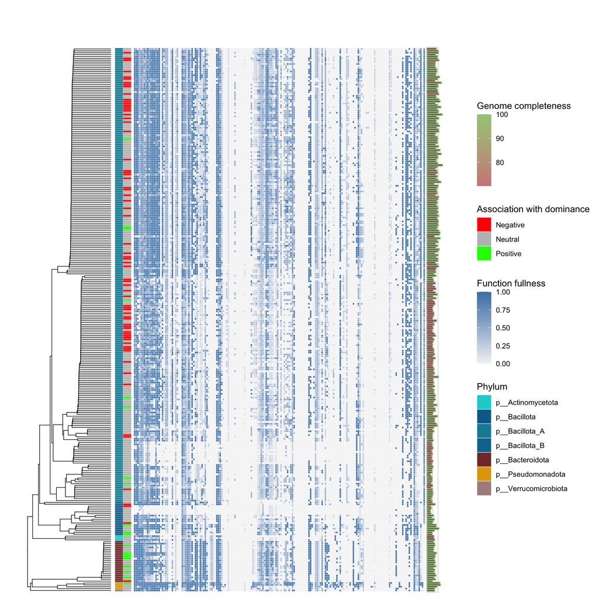

```r
#Add phylum colors next to the tree tips
function_tree <- gheatmap(function_tree, phylum_heatmap, offset=0, width=0.1, colnames=FALSE) +
            scale_fill_manual(values=phylum_colors) +
            labs(fill="Phylum") +
            new_scale_fill()

#Add posteriors
function_tree <- gheatmap(function_tree, postestimate_support, offset=0.2, width=0.1, colnames=FALSE)+
            scale_fill_manual(values=c("red","grey","green")) +
            labs(fill="Association with dominance") +
            new_scale_fill()

#Add functions heatmap
function_tree <- gheatmap(function_tree, function_table, offset=0.55, width=3.5, colnames=FALSE) +
            vexpand(.08) +
            coord_cartesian(clip = "off") +
            scale_fill_gradient(low = "#f4f4f4", high = "steelblue", na.value="white") +
            labs(fill="Function fullness")

#Reset fill scale to use a different colour profile in the heatmap
function_tree <- function_tree + new_scale_fill()

# Add completeness barplots
function_tree <- function_tree +
            geom_fruit(data=genome_metadata,
            geom=geom_bar,
            grid.params=list(axis="x", text.size=2, nbreak = 1),
            axis.params=list(vline=TRUE),
            mapping = aes(x=length, y=genome, color=completeness),
                 offset = 3.8,
                 orientation="y",
                 stat="identity") +
            scale_color_gradient(low = "#cf8888", high = "#a2cc87") +
            labs(color="Genome completeness")

function_tree
```

## Predict responses to dominance

Based on the fitted model, we can predict the structure of the microbial community for each level of dominance for a certain value of sequencing depth.

```r
# Select modelchain of interest
load("hmsc/fit_model1_250_1.Rdata")

gradient = seq(0,1,0.1)
gradientlength = length(gradient)

#Treatment-specific gradient predictions
pred <- constructGradient(m,
                      focalVariable = "dominance",
                      non.focalVariables = list(logseqdepth=list(1)),
                      ngrid=gradientlength) %>%
             predict(m, Gradient = ., expected = TRUE)
predY <- pred %>%
        do.call(rbind,.) %>%
        as.data.frame() %>%
        mutate(dominance=rep(gradient,1000)) %>%
        pivot_longer(-c(dominance), names_to = "genome", values_to = "value")
```

### Plot responses to dominance

The estimated responses of genomes exhibiting significant positive and negative association with dominance.

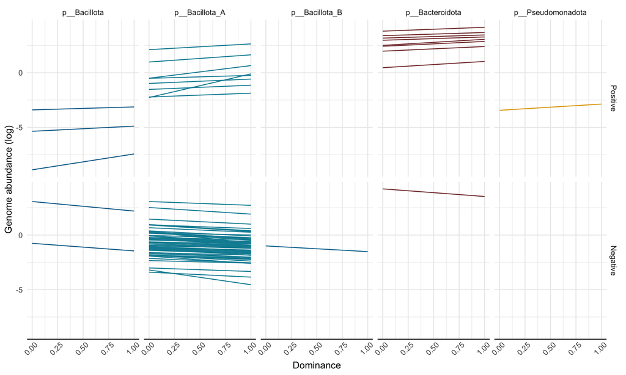

```r
#Get phylum colors from the EHI standard
phylum_colors <- genome_metadata %>%
    left_join(read_tsv("https://raw.githubusercontent.com/earthhologenome/EHI_taxonomy_colour/main/ehi_phylum_colors.tsv"), by=join_by(phylum == phylum)) %>%
    arrange(match(genome, genome_tree$tip.label)) %>%
    select(phylum, colors) %>%
    unique() %>%
    arrange(phylum) %>%
    slice(2:6) %>% #remove phyla absent in this chart
    select(colors) %>%
    pull()

postestimate_support %>%
    rownames_to_column(var="genome") %>%
    left_join(predY, by=join_by(genome==genome)) %>%
    filter(trend != "Neutral") %>%
    #filter(genome %in% predY_asc)  %>% #only display genomes with contrasting dynamics across treatments
    group_by(genome, trend, dominance) %>%
    summarize(value = mean(value, na.rm = TRUE)) %>%
    left_join(genome_metadata, by=join_by(genome == genome)) %>%
    ggplot(aes(x=dominance, y=value, group=genome, color=phylum)) +
        geom_line() +
        scale_color_manual(values=phylum_colors) +
        facet_grid(fct_rev(trend) ~ phylum) +
        labs(y="Genome abundance (log)",x="Dominance") +
        theme(legend.position = "none") +
        theme_minimal() +
         theme(legend.position = "none",
               axis.text.x = element_text(angle = 45, hjust = 0.8,),
               axis.line.x = element_line(size = 0.5, linetype = "solid", colour = "black"),
)
```

## Plot traits linked to trends

### Test functional trait differences

Using Wilcoxon test with Benjamini-Hochberg procedure for FDR, identify functional traits that differ between genomes that are either positively or negatively association with dominance.

```r
postestimate_test <- postestimate_support %>%
      rownames_to_column(var="genome") %>%
      filter(trend != "Neutral") %>%
      left_join(function_table %>% rownames_to_column(var="genome"), by=join_by(genome==genome)) %>%
      pivot_longer(-c(genome,trend), names_to = "trait", values_to = "value") %>%
      group_by(trait) %>%
      summarise(p_value = wilcox.test(value ~ trend)$p.value) %>%
      mutate(p_adjust=p.adjust(p_value, method="BH")) %>%
      filter(p_adjust < 0.01)
```

### Plot functional trait differences

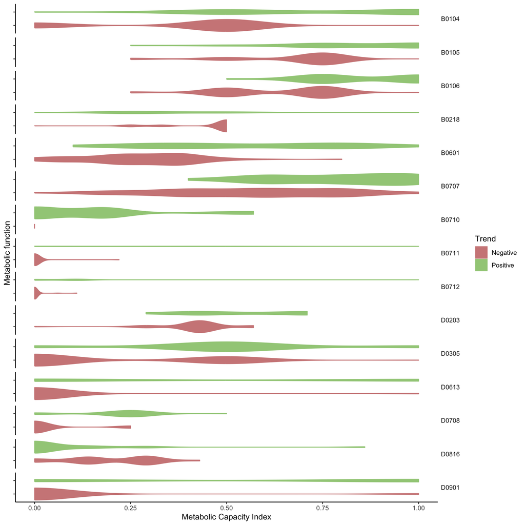

```r
postestimate_support %>%
      rownames_to_column(var="genome") %>%
      filter(trend != "Neutral") %>%
      left_join(function_table %>% rownames_to_column(var="genome"), by=join_by(genome==genome)) %>%
      pivot_longer(-c(genome,trend), names_to = "trait", values_to = "value") %>%
      filter(trait %in% postestimate_test$trait) %>% #filter significantly different functions
      filter(trait != "S0201") %>% #remove structural trait
      ggplot(.,aes(x=value, y=trend, fill=trend, color=trend)) +
          #geom_boxplot(color="black") +
          geom_violin() +
          scale_color_manual(values=c("#cf8888","#a2cc87"))+
          scale_fill_manual(values=c("#cf8888","#a2cc87"))+
          facet_grid(trait ~ ., space="free")+
          theme_classic() +
          labs(x="Metabolic Capacity Index",y="Metabolic function", fill="Trend", color="Trend") +
          theme(strip.text.y = element_text(angle = 0),
                  strip.background = element_blank(),
                        axis.text.y=element_blank())
```